# Modelado de Tópicos con Redes de Documentos - Progreso 1

## Usabilidad de Aplicaciones Móviles: Análisis del Dataset de Palabras

**Asignatura:** Inteligencia Artificial II (ISWZ3402-5451)  
**Docente:** Mario Salvador González  
**Estudiantes:** Gabriel Argüello, Mathew Baquero, Joaquín Chacón, Joel Ibarra, Andrés Jiménez  
**Dataset:** Palabras seleccionadas por usuarios para describir la usabilidad de una app móvil  
**Fuente:** words_ux.csv

### Descripción del Proyecto

Este notebook implementa un pipeline de **modelado de tópicos basado en redes de documentos**. En lugar de aplicar modelos probabilísticos tradicionales, como LDA o NMF, se utiliza una representación relacional donde cada documento se convierte en un nodo y la similitud entre documentos se convierte en una arista ponderada. Bajo esta lógica, un tópico no se define como una distribución probabilística de palabras, sino como una **comunidad de documentos** que comparten patrones de vocabulario.

La unidad de análisis es cada fila del dataset. Cada fila representa un conjunto de palabras elegido por un usuario para describir la usabilidad de una aplicación móvil. Por esa razón, el dato se interpreta como un documento corto, discreto y semiestructurado. No es una oración natural, sino una selección de atributos. Esta diferencia metodológica es importante porque justifica usar una matriz binaria de presencia/ausencia y medidas de similitud adecuadas para conjuntos de palabras.

El objetivo general es comparar dos formas de construir la red de documentos, una basada en **similitud Coseno** y otra en **similitud Jaccard**, y evaluar cuál produce comunidades más interpretables como tópicos. La comparación no se limita a ver el grafo visualmente; se calculan métricas de estructura y coherencia, se generan palabras representativas por comunidad y se toma una decisión final justificada.

### Enfoque metodológico

El flujo completo sigue esta lógica:

1. Convertir respuestas de usuarios en documentos comparables.
2. Transformar los documentos en una DTM binaria.
3. Calcular similitud entre cada par de documentos.
4. Construir una red ponderada para cada medida de similitud.
5. Filtrar aristas débiles para conservar relaciones informativas.
6. Detectar comunidades con Louvain.
7. Interpretar cada comunidad como un tópico.
8. Comparar resultados y seleccionar la medida más adecuada.

Esta secuencia es apropiada porque traduce el problema de modelado de tópicos a un problema de detección de comunidades en redes. El supuesto central es que documentos que comparten vocabulario relevante tenderán a conectarse más fuertemente y, por lo tanto, a agruparse en comunidades temáticas.

## Paso 0: Importaciones y Configuración

En este paso se cargan las librerías necesarias: manejo de datos (`pandas`, `numpy`), vectorización de texto (`sklearn`), cálculo de similitudes, construcción de grafos (`networkx`), detección de comunidades Louvain (`python-louvain`) y visualización (`matplotlib`, `seaborn`).

La selección de herramientas responde directamente a las etapas metodológicas del proyecto. `pandas` permite leer el CSV y mantener una tabla auditable; `CountVectorizer` permite convertir documentos en vectores binarios de manera reproducible; `cosine_similarity` y `pairwise_distances` permiten calcular matrices de similitud; `networkx` permite construir grafos ponderados y calcular propiedades de red; `community_louvain` implementa el algoritmo de Louvain, una de las opciones sugeridas por la consigna.

También se fija una semilla aleatoria para que las visualizaciones por layout de resortes y la partición Louvain sean reproducibles. Esto no es un detalle menor: Louvain y los layouts de grafos pueden producir resultados visuales o particiones ligeramente distintas si no se controla el estado aleatorio. Fijar `random_state=42` permite que otra persona ejecute el notebook y obtenga la misma organización de comunidades.

Se usa una instalación condicional de `python-louvain`: si la librería ya está disponible, se importa directamente; si no existe en el entorno, se instala. Esta decisión mantiene el notebook portable sin obligar a reinstalar dependencias en cada ejecución.

```python
import pandas as pd
import numpy as np
import matplotlib.pyplot as plt
import matplotlib.colors as mcolors
import matplotlib.patches as mpatches
import seaborn as sns
import networkx as nx
from sklearn.feature_extraction.text import CountVectorizer
from sklearn.metrics.pairwise import cosine_similarity, pairwise_distances
from collections import Counter
import math
import warnings

try:
    import community as community_louvain
except ImportError:
    import sys
    import subprocess
    subprocess.check_call([sys.executable, '-m', 'pip', 'install', 'python-louvain', '--quiet'])
    import community as community_louvain

warnings.filterwarnings('ignore')
np.random.seed(42)
plt.rcParams['figure.dpi'] = 100
plt.rcParams['figure.figsize'] = (10, 6)
sns.set_style('whitegrid')
COLORS = list(mcolors.TABLEAU_COLORS.values())

print('Todas las librerías cargadas correctamente.')
```

```
Todas las librerías cargadas correctamente.
```

## Paso 1: Preparación de los Datos

El dataset contiene una sola columna (`Words`) donde cada fila representa las palabras seleccionadas por un usuario para describir la usabilidad de una app móvil. Cada fila se trata como un **documento**.

**Preprocesamiento aplicado:**

- Eliminar espacios al inicio y final.
- Descartar filas vacías o nulas.
- Convertir todo a minúsculas.
- Eliminar documentos duplicados.

### Concepto: Qué significa un documento en este proyecto

En análisis de texto, un documento suele ser una frase, un comentario, un artículo o cualquier unidad textual que se desea analizar. En este caso, el documento no es texto narrativo, sino una lista de palabras seleccionadas por un usuario. Aun así, funciona como documento porque contiene una representación de la percepción del usuario sobre la app. Dos documentos son similares si dos usuarios escogieron palabras parecidas.

Este punto es clave para interpretar correctamente el proyecto. No se está analizando gramática, orden de palabras ni sintaxis. Lo importante es el conjunto de atributos elegido por cada usuario. Por eso, el análisis se centra en **presencia o ausencia de términos**, no en conteos repetidos ni en posiciones dentro de una oración.

### Razón de las decisiones de preprocesamiento

El preprocesamiento es deliberadamente conservador. No se aplican stemming, lematización ni eliminación de palabras frecuentes porque el dataset no contiene texto libre tradicional, sino etiquetas seleccionadas por usuarios. Palabras como `easytouse`, `poor-quality` o `time-consuming` son categorías semánticas completas y conviene preservarlas tal como aparecen para no perder interpretabilidad en los tópicos.

Convertir a minúsculas evita que `Fast` y `fast` sean tratados como términos distintos. Eliminar filas vacías evita documentos sin información, que generarían vectores completamente en cero y podrían distorsionar algunas medidas. Eliminar duplicados evita contar dos veces exactamente la misma selección de palabras como si fueran percepciones independientes.

### Qué se revisa en este paso

La revisión descriptiva inicial permite confirmar tres elementos clave antes de construir la red: número de documentos disponibles, tamaño del vocabulario y distribución de longitud de documentos. Esto importa porque documentos muy cortos o muy largos afectan la similitud Coseno y Jaccard de manera distinta. Por ejemplo, un documento con una sola palabra puede parecer relativamente cercano a otro si comparten ese término, mientras que un documento muy largo puede compartir varias palabras con muchos documentos distintos.

```python
URL = 'https://raw.githubusercontent.com/marsgr6/estadistica-ux/main/data/words_ux.csv'

df_raw = pd.read_csv(URL)
print(f'Forma original: {df_raw.shape}')
print(f'Columnas: {df_raw.columns.tolist()}')
df_raw.head(10)
```

```
Forma original: (52, 1)
Columnas: ['Words']
```

|  | Words |
| --- | --- |
| 0 | Boring Consistent EasyToUse Fast Simple Useful |
| 1 | Boring Confusing Contradictory Difficult EasyT... |
| 2 | Confusing Fast Old Unattractive Useful |
| 3 | Complex Confusing Creative Difficult |
| 4 | Advanced Clean Credible Difficult Effective New |
| 5 | Boring Clear EasyToUse |
| 6 | Unattractive Useful |
| 7 | Advanced Clean Confusing Consistent EasyToUse ... |
| 8 | Advanced Clean Confusing Consistent EasyToUse ... |
| 9 | Advanced Attractive Clean Comprehensive Consis... |

```python
col = df_raw.columns[0]

df = df_raw.copy()
df[col] = df[col].astype(str).str.strip()
df = df[df[col].str.len() > 0]
df = df[df[col] != 'nan']
df[col] = df[col].str.lower()
df = df.drop_duplicates(subset=col).reset_index(drop=True)
df.index.name = 'doc_id'

print(f'Tras preprocesamiento: {df.shape[0]} documentos')
df.head(8)
```

```
Tras preprocesamiento: 52 documentos
```

| doc_id | Words |
| --- | --- |
| 0 | boring consistent easytouse fast simple useful |
| 1 | boring confusing contradictory difficult easyt... |
| 2 | confusing fast old unattractive useful |
| 3 | complex confusing creative difficult |
| 4 | advanced clean credible difficult effective new |
| 5 | boring clear easytouse |
| 6 | unattractive useful |
| 7 | advanced clean confusing consistent easytouse ... |

```python
all_words = [w for doc in df[col] for w in doc.split()]
vocab     = sorted(set(all_words))
word_freq = Counter(all_words)
doc_lengths = df[col].apply(lambda x: len(x.split()))

print(f'Vocabulario (palabras únicas): {len(vocab)}')
print(f'Total de tokens: {len(all_words)}')
print(f'Palabras/doc — mín: {doc_lengths.min()}, máx: {doc_lengths.max()}, media: {doc_lengths.mean():.1f}')
print(f'\nTop 20 palabras más frecuentes:')
pd.Series(word_freq).sort_values(ascending=False).head(20)
```

```
Vocabulario (palabras únicas): 84
Total de tokens: 541
Palabras/doc — mín: 1, máx: 52, media: 10.4

Top 20 palabras más frecuentes:
```

```
easytouse        23
creative         22
advanced         21
useful           18
attractive       18
clear            18
effective        18
fast             17
simple           17
new              16
boring           15
consistent       15
clean            15
credible         14
confusing        14
usable           13
convenient       12
friendly         11
efficient        11
comprehensive    11
dtype: int64
```

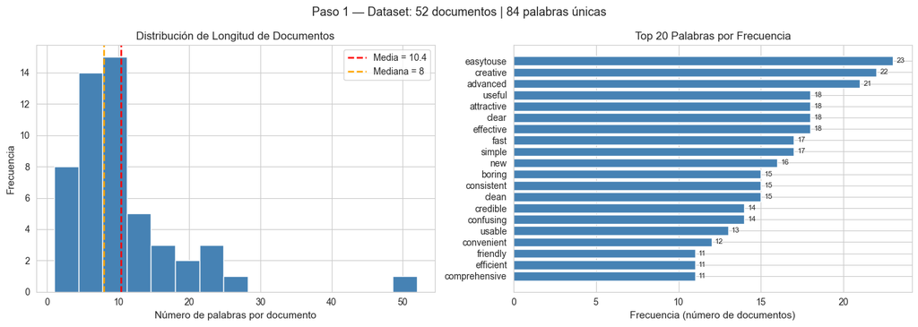

```python
fig, axes = plt.subplots(1, 2, figsize=(14, 5))

axes[0].hist(doc_lengths, bins=15, color='steelblue', edgecolor='white')
axes[0].axvline(doc_lengths.mean(),   color='red',    linestyle='--', linewidth=1.8,
                label=f'Media = {doc_lengths.mean():.1f}')
axes[0].axvline(doc_lengths.median(), color='orange', linestyle='--', linewidth=1.8,
                label=f'Mediana = {doc_lengths.median():.0f}')
axes[0].set_xlabel('Número de palabras por documento', fontsize=11)
axes[0].set_ylabel('Frecuencia', fontsize=11)
axes[0].set_title('Distribución de Longitud de Documentos', fontsize=12)
axes[0].legend(fontsize=10)

top_words = pd.Series(word_freq).sort_values(ascending=False).head(20)
bars = axes[1].barh(top_words.index[::-1], top_words.values[::-1],
                    color='steelblue', edgecolor='white')
axes[1].set_xlabel('Frecuencia (número de documentos)', fontsize=11)
axes[1].set_title('Top 20 Palabras por Frecuencia', fontsize=12)
for bar, val in zip(bars, top_words.values[::-1]):
    axes[1].text(bar.get_width() + 0.2, bar.get_y() + bar.get_height()/2,
                 str(val), va='center', fontsize=8)

plt.suptitle(f'Paso 1 — Dataset: {df.shape[0]} documentos | {len(vocab)} palabras únicas',
             fontsize=13)
plt.tight_layout()
plt.show()
```

### Interpretación del Paso 1

La salida confirma que el dataset tiene un tamaño manejable para análisis de red. El vocabulario contiene suficientes términos para que existan patrones de coincidencia, pero no tantos como para hacer ininterpretable la DTM. La distribución de longitud de documentos permite anticipar un punto metodológico importante: no todos los usuarios seleccionaron la misma cantidad de palabras.

Esa variación justifica comparar Coseno y Jaccard. Coseno normaliza por longitud vectorial, mientras que Jaccard penaliza el tamaño de la unión de palabras. Si todos los documentos tuvieran exactamente la misma longitud, ambas medidas tenderían a parecerse más. Como las longitudes varían, la comparación es relevante.

## Paso 2: Construcción de la Matriz Documento-Término (DTM)

La **DTM** es una matriz `(n_documentos × n_términos)` donde cada celda vale 1 si la palabra está presente y 0 si no.

Usamos **codificación binaria** con `CountVectorizer(binary=True)` porque cada usuario selecciona cada palabra como máximo una vez, y tanto Coseno como Jaccard son adecuadas para vectores binarios.

### Concepto: Qué representa la DTM

La matriz documento-término transforma información cualitativa en una estructura numérica. Cada fila representa un usuario/documento y cada columna representa una palabra única del vocabulario. Si un usuario seleccionó una palabra, la celda correspondiente vale 1; si no la seleccionó, vale 0. Así, cada documento queda representado como un vector binario.

Por ejemplo, si dos documentos activan muchas columnas iguales, comparten vocabulario y probablemente expresan percepciones similares. Si no activan ninguna columna en común, su similitud será cero bajo Coseno y Jaccard. Esta matriz es, por lo tanto, el puente entre el dataset original y la red de documentos.

### Razón de usar una DTM binaria

La consigna permite usar frecuencias, pero en este dataset las palabras no aparecen como texto libre repetido: son selecciones de atributos. Si una palabra aparece en una fila, lo importante es que fue seleccionada, no cuántas veces se repitió. En consecuencia, una DTM binaria representa mejor la naturaleza del dato.

Usar frecuencia tradicional podría introducir una idea falsa de intensidad si una palabra apareciera repetida por error en una fila. La codificación binaria evita ese problema y alinea el análisis con la interpretación de encuesta o selección múltiple: cada palabra está presente o ausente.

### Decisiones técnicas

Se usa `CountVectorizer(binary=True)` porque automatiza la construcción de vocabulario y matriz de presencia. El patrón `token_pattern` conserva términos alfabéticos y palabras compuestas con guion; esto evita perder señales relevantes como `poor-quality` o `time-consuming`. La matriz se convierte a `DataFrame` para que las columnas mantengan nombres de palabras y los resultados sean interpretables.

La visualización por heatmap no se utiliza para descubrir tópicos directamente, sino como control de calidad. Permite verificar que la matriz sea efectivamente binaria, que la dispersión sea alta como se espera en documentos cortos y que no exista un problema evidente de codificación.

```python
vectorizer = CountVectorizer(binary=True, token_pattern=r'[a-z][a-z-]+')
X = vectorizer.fit_transform(df[col])
feature_names = vectorizer.get_feature_names_out()

dtm = pd.DataFrame(X.toarray(), columns=feature_names)
dtm.index.name = 'doc_id'

print(f'Forma de la DTM: {dtm.shape}  ({dtm.shape[0]} documentos × {dtm.shape[1]} términos)')
print(f'Dispersión: {100 * (1 - dtm.values.sum() / dtm.size):.1f}%')
dtm.iloc[:8, :10]
```

```
Forma de la DTM: (52, 84)  (52 documentos × 84 términos)
Dispersión: 87.6%
```

| doc_id | advanced | ambiguous | attractive | boring | bright | busy | clean | clear | complex | comprehensive |
| --- | --- | --- | --- | --- | --- | --- | --- | --- | --- | --- |
| 0 | 0 | 0 | 0 | 1 | 0 | 0 | 0 | 0 | 0 | 0 |
| 1 | 0 | 0 | 0 | 1 | 0 | 0 | 0 | 0 | 0 | 0 |
| 2 | 0 | 0 | 0 | 0 | 0 | 0 | 0 | 0 | 0 | 0 |
| 3 | 0 | 0 | 0 | 0 | 0 | 0 | 0 | 0 | 1 | 0 |
| 4 | 1 | 0 | 0 | 0 | 0 | 0 | 1 | 0 | 0 | 0 |
| 5 | 0 | 0 | 0 | 1 | 0 | 0 | 0 | 1 | 0 | 0 |
| 6 | 0 | 0 | 0 | 0 | 0 | 0 | 0 | 0 | 0 | 0 |
| 7 | 1 | 0 | 0 | 0 | 0 | 0 | 1 | 0 | 0 | 0 |

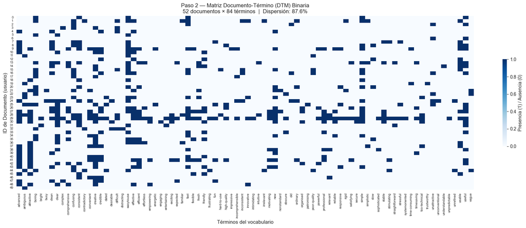

```python
fig, ax = plt.subplots(figsize=(18, 7))
sns.heatmap(
    dtm.iloc[:50, :], cmap='Blues', linewidths=0,
    xticklabels=True, yticklabels=True, ax=ax,
    cbar_kws={'label': 'Presencia (1) / Ausencia (0)', 'shrink': 0.5}
)
ax.set_title(
    f'Paso 2 — Matriz Documento-Término (DTM) Binaria\n'
    f'{dtm.shape[0]} documentos × {dtm.shape[1]} términos  |  '
    f'Dispersión: {100*(1-dtm.values.sum()/dtm.size):.1f}%',
    fontsize=12
)
ax.set_xlabel('Términos del vocabulario', fontsize=11)
ax.set_ylabel('ID de Documento (usuario)', fontsize=11)
ax.tick_params(axis='x', labelsize=7, rotation=90)
ax.tick_params(axis='y', labelsize=7)
plt.tight_layout()
plt.show()
```

### Interpretación del Paso 2

La forma de la DTM confirma que cada documento fue representado frente al vocabulario completo. La dispersión alta es esperable porque cada usuario selecciona solo una parte pequeña de las palabras disponibles. Esto no es un problema; al contrario, refleja la naturaleza de documentos cortos y conjuntos de atributos.

El heatmap permite observar visualmente esa dispersión. A partir de esta matriz, dos documentos serán similares cuando compartan columnas activas. Por lo tanto, cualquier decisión posterior sobre similitud, redes y comunidades depende directamente de esta representación binaria.

## Paso 3: Medidas de Similitud

### Similitud Coseno

$$\text{coseno}(A, B) = \frac{A \cdot B}{\|A\| \cdot \|B\|}$$ Mide el ángulo entre vectores. Insensible a la longitud del documento.

### Similitud Jaccard

$$J(A, B) = \frac{|A \cap B|}{|A \cup B|}$$ Mide qué proporción del vocabulario combinado es compartido. Ideal para vectores binarios.

**Diferencia clave:** Jaccard penaliza cuando un usuario eligió muchas palabras que el otro no tiene: más justo para documentos de longitudes distintas.

### Concepto: Por qué se calculan similitudes

Para construir una red de documentos se necesita definir cuándo dos documentos están relacionados y con qué intensidad. La similitud cumple esa función. Cada par de documentos recibe un valor entre 0 y 1, donde 0 significa que no comparten palabras y 1 significa coincidencia perfecta bajo la medida correspondiente.

El resultado de este paso es una matriz cuadrada de tamaño `n_documentos × n_documentos`. La celda `(i, j)` contiene la similitud entre el documento `i` y el documento `j`. Como las medidas usadas son simétricas, la matriz también es simétrica. La diagonal se fija en cero para evitar auto-conexiones: un documento siempre es idéntico a sí mismo, pero esa relación no ayuda a descubrir comunidades entre documentos distintos.

### Por qué se eligen Coseno y Jaccard

La consigna pide comparar dos medidas de similitud. Coseno y Jaccard son una combinación útil porque ambas son comunes en análisis de texto, pero responden a intuiciones distintas.

Coseno interpreta cada documento como un vector y compara su orientación. En una DTM binaria, el producto punto cuenta cuántas palabras comparten dos documentos, mientras que la normalización por las normas reduce el efecto del tamaño del documento. Esta medida puede funcionar bien cuando interesa saber si dos documentos apuntan en una dirección similar dentro del espacio de términos.

Jaccard interpreta cada documento como un conjunto de palabras. Su numerador es la intersección de palabras compartidas y su denominador es la unión de todas las palabras presentes en ambos documentos. Por eso penaliza explícitamente las palabras no compartidas. Esta propiedad es especialmente razonable aquí, porque los documentos son selecciones binarias de atributos de usabilidad.

### Diferencia práctica entre ambas medidas

Si dos documentos comparten pocas palabras, pero ambos son cortos, Coseno puede asignar una similitud relativamente alta porque la normalización por longitud favorece la coincidencia proporcional. Jaccard, en cambio, compara las palabras compartidas contra todo el vocabulario combinado de ambos documentos. Por eso suele ser más estricta cuando hay muchas palabras que no coinciden.

Esta diferencia es importante para el resultado final. Si Coseno genera comunidades más amplias, puede estar capturando afinidad general. Si Jaccard genera comunidades más separadas, puede estar capturando coincidencia más específica de conjuntos de palabras. El notebook no asume de antemano cuál es mejor: ambas se calculan, se grafican y se evalúan posteriormente.

### Validación aplicada

Después de calcular las matrices se verifica que sean cuadradas, simétricas, con diagonal cero y valores dentro de `[0, 1]`. Además, se comprueba manualmente un valor de Jaccard para confirmar que la implementación corresponde a la definición teórica de intersección sobre unión. Estas validaciones no cambian resultados; solo aumentan la trazabilidad técnica del análisis.

```python
X_arr = X.toarray().astype(float)

cos_sim = cosine_similarity(X_arr)
np.fill_diagonal(cos_sim, 0)

jac_sim = 1 - pairwise_distances(X_arr, metric='jaccard')
np.fill_diagonal(jac_sim, 0)

print(f'Coseno  — shape: {cos_sim.shape} | no nulos: {np.count_nonzero(cos_sim)} | media: {cos_sim[cos_sim>0].mean():.4f} | máx: {cos_sim.max():.4f}')
print(f'Jaccard — shape: {jac_sim.shape} | no nulos: {np.count_nonzero(jac_sim)} | media: {jac_sim[jac_sim>0].mean():.4f} | máx: {jac_sim.max():.4f}')
```

```
Coseno  — shape: (52, 52) | no nulos: 2022 | media: 0.2633 | máx: 0.6940
Jaccard — shape: (52, 52) | no nulos: 2022 | media: 0.1428 | máx: 0.5312
```

```python
# Validación técnica de matrices de similitud
# Estas comprobaciones no modifican los resultados; solo verifican que las matrices sean coherentes.

def validate_similarity_matrix(sim_matrix, name):
    assert sim_matrix.shape[0] == sim_matrix.shape[1], f'{name}: la matriz no es cuadrada'
    assert np.allclose(sim_matrix, sim_matrix.T), f'{name}: la matriz no es simétrica'
    assert np.allclose(np.diag(sim_matrix), 0), f'{name}: la diagonal debe ser cero para evitar self-loops'
    assert sim_matrix.min() >= 0 and sim_matrix.max() <= 1 + 1e-12, f'{name}: valores fuera de [0, 1]'
    print(f'{name}: matriz cuadrada, simétrica, diagonal cero y rango válido [0,1].')

validate_similarity_matrix(cos_sim, 'Coseno')
validate_similarity_matrix(jac_sim, 'Jaccard')

pairs = np.argwhere(np.triu(jac_sim, k=1) > 0)
i, j = pairs[0]
set_i = set(np.where(X_arr[i] > 0)[0])
set_j = set(np.where(X_arr[j] > 0)[0])
manual_jaccard = len(set_i & set_j) / len(set_i | set_j)
assert np.isclose(jac_sim[i, j], manual_jaccard)
print(f'Jaccard manual doc {i}-{j}: {manual_jaccard:.4f} = matriz {jac_sim[i, j]:.4f}')
```

```
Coseno: matriz cuadrada, simétrica, diagonal cero y rango válido [0,1].
Jaccard: matriz cuadrada, simétrica, diagonal cero y rango válido [0,1].
Jaccard manual doc 0-1: 0.2222 = matriz 0.2222
```

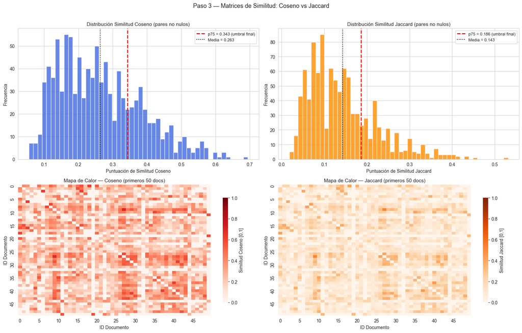

```python
cos_vals = cos_sim[np.triu_indices_from(cos_sim, k=1)]
jac_vals = jac_sim[np.triu_indices_from(jac_sim, k=1)]

fig, axes = plt.subplots(2, 2, figsize=(16, 10))

p75_cos = np.percentile(cos_vals[cos_vals > 0], 75)
p75_jac = np.percentile(jac_vals[jac_vals > 0], 75)

for ax, vals, color, name, p75 in [
    (axes[0,0], cos_vals[cos_vals>0], 'royalblue',  'Coseno',  p75_cos),
    (axes[0,1], jac_vals[jac_vals>0], 'darkorange', 'Jaccard', p75_jac),
]:
    ax.hist(vals, bins=50, color=color, edgecolor='white', alpha=0.8)
    ax.axvline(p75, color='red', linestyle='--', linewidth=2,
               label=f'p75 = {p75:.3f} (umbral final)')
    ax.axvline(vals.mean(), color='black', linestyle=':', linewidth=1.5,
               label=f'Media = {vals.mean():.3f}')
    ax.set_title(f'Distribución Similitud {name} (pares no nulos)', fontsize=11)
    ax.set_xlabel(f'Puntuación de Similitud {name}')
    ax.set_ylabel('Frecuencia')
    ax.legend(fontsize=9)

N_SHOW = 50
for ax, sim, cmap, name, label in [
    (axes[1,0], cos_sim, 'Reds',    'Coseno',  'Similitud Coseno [0,1]'),
    (axes[1,1], jac_sim, 'Oranges', 'Jaccard', 'Similitud Jaccard [0,1]'),
]:
    sns.heatmap(sim[:N_SHOW, :N_SHOW], cmap=cmap, ax=ax,
                xticklabels=5, yticklabels=5, vmin=0, vmax=1,
                cbar_kws={'label': label, 'shrink': 0.8})
    ax.set_title(f'Mapa de Calor — {name} (primeros {N_SHOW} docs)', fontsize=11)
    ax.set_xlabel('ID Documento')
    ax.set_ylabel('ID Documento')

plt.suptitle('Paso 3 — Matrices de Similitud: Coseno vs Jaccard', fontsize=13, y=1.01)
plt.tight_layout()
plt.show()
```

### Interpretación del Paso 3

Las distribuciones de similitud muestran que la mayoría de relaciones entre documentos no son extremadamente fuertes. Esto es normal en datos de vocabulario breve: muchos usuarios comparten algunas palabras, pero pocos comparten gran parte de su selección completa.

La diferencia de escala entre Coseno y Jaccard debe recordarse durante todo el análisis. No conviene comparar directamente un valor de Coseno con un valor de Jaccard como si significaran lo mismo. Por eso los umbrales se calculan por percentil dentro de cada medida y la evaluación final usa métricas relativas.

## Paso 4: Trimming Previo: Eliminar Aristas con Similitud = 0

Antes de aplicar el umbral percentílico realizamos un **trimming previo**: construimos el grafo completo incluyendo únicamente las aristas con similitud **estrictamente mayor que cero**.

**Justificación:** Dos usuarios con similitud = 0 no comparten ninguna palabra. No existe relación semántica observable entre ellos bajo la representación elegida. Incluirlos solo añade ruido a la red sin aportar información útil para la detección de tópicos.

### Concepto: Red de documentos

Una red o grafo está compuesta por nodos y aristas. En este proyecto, cada nodo representa un documento, es decir, la selección de palabras de un usuario. Cada arista representa una relación de similitud entre dos documentos. Como la similitud tiene intensidad, la arista es ponderada: su peso es el valor de Coseno o Jaccard.

El grafo es no dirigido porque la similitud entre el documento `i` y el documento `j` es igual a la similitud entre `j` e `i`. No se agregan self-loops porque no interesa conectar un documento consigo mismo. Esta estructura permite pasar de una matriz de similitud a un objeto de red sobre el que se pueden calcular comunidades.

### Razón del trimming previo

La consigna pide construir una red y aplicar un umbral para recortar aristas débiles, pero también advierte evitar un sobre-recorte inicial. Por eso se separan dos decisiones: primero se eliminan solo las aristas sin información (`sim = 0`) y luego se analiza qué umbral adicional conviene aplicar.

Eliminar similitud cero no es una decisión agresiva porque esas aristas no representan ningún solapamiento de vocabulario. Mantenerlas haría el grafo artificialmente denso y podría dificultar la lectura de la estructura real. En cambio, conservar todas las aristas con `sim > 0` permite observar la red informativa completa antes del recorte final.

### Cómo leer las métricas del grafo

El número de aristas indica cuántas relaciones se conservan. La densidad indica qué proporción de todos los pares posibles están conectados. El número de componentes conectados permite saber si la red se fragmenta. La mayor componente conectada muestra qué porcentaje de documentos permanece en el bloque principal de análisis.

Estas métricas se revisan antes de Louvain porque un grafo demasiado denso puede ocultar comunidades y un grafo demasiado recortado puede fragmentarse en exceso. La meta no es maximizar aristas, sino conservar suficientes relaciones para detectar estructura temática sin saturar la red de conexiones débiles.

```python
def build_graph(sim_matrix, threshold=0.0):
    """Construir grafo no dirigido ponderado con aristas donde sim > threshold."""
    n = sim_matrix.shape[0]
    G = nx.Graph()
    G.add_nodes_from(range(n))
    rows, cols = np.where(
        (sim_matrix > threshold) &
        (np.arange(n)[:, None] < np.arange(n)[None, :])
    )
    for r, c in zip(rows, cols):
        G.add_edge(int(r), int(c), weight=float(sim_matrix[r, c]))
    return G

def graph_stats(G, name=''):
    n   = G.number_of_nodes()
    m   = G.number_of_edges()
    den = m / (n*(n-1)/2) if n > 1 else 0
    ccs = list(nx.connected_components(G))
    lcc = max(len(c) for c in ccs)
    avg = np.mean([d for _, d in G.degree()])
    iso = sum(1 for _, d in G.degree() if d == 0)
    print(f'[{name}]')
    print(f'  Nodos: {n} | Aristas: {m} | Densidad: {den:.4f}')
    print(f'  Componentes: {len(ccs)} | Mayor CC: {lcc} ({100*lcc/n:.1f}%)')
    print(f'  Grado medio: {avg:.1f} | Nodos aislados: {iso}')
    return {'nodes': n, 'edges': m, 'density': den,
            'components': len(ccs), 'largest_cc': lcc, 'avg_deg': avg}

# --- TRIMMING PREVIO: solo aristas con sim > 0 ---
G_cos_pre = build_graph(cos_sim, threshold=0.0)
G_jac_pre = build_graph(jac_sim, threshold=0.0)

n_docs = cos_sim.shape[0]
total_pares = n_docs * (n_docs - 1) // 2

print('=== GRAFO COSENO — Trimming Previo (sim > 0) ===')
s_cp = graph_stats(G_cos_pre, 'Coseno pre-trim')
print(f'  Aristas eliminadas (sim=0): {total_pares - s_cp["edges"]} de {total_pares} '
      f'({100*(total_pares-s_cp["edges"])/total_pares:.1f}%)')
print()
print('=== GRAFO JACCARD — Trimming Previo (sim > 0) ===')
s_jp = graph_stats(G_jac_pre, 'Jaccard pre-trim')
print(f'  Aristas eliminadas (sim=0): {total_pares - s_jp["edges"]} de {total_pares} '
      f'({100*(total_pares-s_jp["edges"])/total_pares:.1f}%)')
```

```
=== GRAFO COSENO — Trimming Previo (sim > 0) ===
[Coseno pre-trim]
  Nodos: 52 | Aristas: 1011 | Densidad: 0.7624
  Componentes: 1 | Mayor CC: 52 (100.0%)
  Grado medio: 38.9 | Nodos aislados: 0
  Aristas eliminadas (sim=0): 315 de 1326 (23.8%)

=== GRAFO JACCARD — Trimming Previo (sim > 0) ===
[Jaccard pre-trim]
  Nodos: 52 | Aristas: 1011 | Densidad: 0.7624
  Componentes: 1 | Mayor CC: 52 (100.0%)
  Grado medio: 38.9 | Nodos aislados: 0
  Aristas eliminadas (sim=0): 315 de 1326 (23.8%)
```

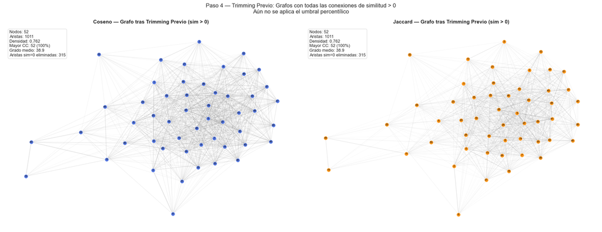

```python
def draw_weighted_graph_overview(G, title, ax, node_color, seed=42):
    """Dibuja una red ponderada con mayor separación visual sin alterar el grafo."""
    pos = nx.spring_layout(G, weight='weight', seed=seed, k=0.85,
                           iterations=300, scale=2.4)
    weights = [G[u][v]['weight'] for u, v in G.edges()]
    max_w = max(weights) if weights else 1

    for (u, v), w in zip(G.edges(), weights):
        nx.draw_networkx_edges(G, pos, edgelist=[(u, v)],
                               width=0.25 + 1.1 * (w / max_w),
                               alpha=0.05 + 0.22 * (w / max_w),
                               edge_color='gray', ax=ax)

    nx.draw_networkx_nodes(G, pos, node_color=node_color, node_size=70,
                           alpha=0.9, edgecolors='white', linewidths=0.6, ax=ax)
    nx.draw_networkx_labels(G, pos, font_size=6, font_color='#222222', ax=ax)

    n, m = G.number_of_nodes(), G.number_of_edges()
    den = m / (n * (n - 1) / 2)
    lcc = max(len(c) for c in nx.connected_components(G))
    info = (f'Nodos: {n}\nAristas: {m}\nDensidad: {den:.3f}\n'
            f'Mayor CC: {lcc} ({100*lcc/n:.0f}%)\n'
            f'Grado medio: {np.mean([d for _, d in G.degree()]):.1f}\n'
            f'Aristas sim=0 eliminadas: {total_pares-m}')
    ax.text(0.02, 0.98, info, transform=ax.transAxes, fontsize=9,
            verticalalignment='top',
            bbox=dict(boxstyle='round', facecolor='white', alpha=0.88, edgecolor='#dddddd'))
    ax.set_title(title, fontsize=11, fontweight='bold')
    ax.axis('off')

fig, axes = plt.subplots(1, 2, figsize=(18, 7))
draw_weighted_graph_overview(G_cos_pre, 'Coseno — Grafo tras Trimming Previo (sim > 0)', axes[0], 'royalblue', seed=42)
draw_weighted_graph_overview(G_jac_pre, 'Jaccard — Grafo tras Trimming Previo (sim > 0)', axes[1], 'darkorange', seed=42)
plt.suptitle('Paso 4 — Trimming Previo: Grafos con todas las conexiones de similitud > 0\n'
             'Aún no se aplica el umbral percentílico', fontsize=12)
plt.tight_layout()
plt.show()
```

## Paso 5: Analisis de Umbral, Percentil 75 y Grafo Final

Sobre los grafos pre-filtrados analizamos varios niveles de recorte antes de fijar el **percentil 75** como umbral definitivo. Esta version incluye como punto inicial el grafo completo informativo, es decir, todas las aristas con similitud **estrictamente mayor que cero** (`sim > 0`). Ese punto se muestra como percentil 0 solo para la visualizacion de sensibilidad: representa "sin umbral percentilico adicional".

### Concepto: Que significa usar un percentil como umbral

Un umbral absoluto, por ejemplo `sim > 0.20`, puede ser problematico cuando se comparan medidas distintas. Coseno y Jaccard no distribuyen sus valores de la misma manera. Un valor de 0.20 puede ser moderado para una medida y relativamente alto para otra. Por eso se utiliza un percentil calculado dentro de cada distribucion de similitudes no nulas.

El percentil 75 significa que se conserva una arista solo si su similitud esta por encima del 75% de las similitudes positivas observadas para esa medida. En terminos practicos, se retienen las conexiones mas fuertes de cada red, respetando la escala propia de Coseno y de Jaccard.

### Por que el percentil se calcula sobre similitudes no nulas

Las similitudes cero ya fueron eliminadas en el trimming previo porque representan ausencia total de palabras compartidas. Si se incluyeran ceros en el calculo del percentil, el umbral podria desplazarse artificialmente hacia abajo, especialmente si hubiera muchos pares sin solapamiento. Calcular el percentil sobre valores `> 0` hace que el recorte se base unicamente en relaciones informativas.

### Razon de seleccionar p75

Se evalua el comportamiento desde el grafo completo informativo (`sim > 0`) hasta percentiles altos para observar como cambian las aristas, la densidad y el tamano de la mayor componente conectada. El percentil 75 se selecciona porque reduce de forma importante la densidad del grafo, pero conserva casi todos los documentos dentro de la mayor componente. En los resultados, ambos grafos finales mantienen 52 nodos, 253 aristas, densidad aproximada de 0.191 y una mayor componente con 51 documentos.

Esto representa un equilibrio metodologico, ya que el grafo queda lo suficientemente filtrado para que Louvain pueda distinguir comunidades, pero no tan fragmentado como para perder demasiados documentos o convertir muchos casos en aislados.

### Control visual contra interpretaciones incompletas

Las graficas de sensibilidad usan el rango completo de comparacion y fijan el eje vertical desde cero para aristas, conectividad y densidad. Asi se evita que una escala recortada exagere visualmente la caida entre percentiles. La linea roja marca p75 como decision metodologica, no como inicio del fenomeno observado.

### Convencion tecnica usada

El grafo final conserva aristas con similitud **mayor** al umbral (`sim > p75`). Esta convencion evita self-loops y mantiene una regla estricta. Si existieran muchos empates exactamente en el percentil, el numero de aristas podria no ser exactamente el 25% matematico, pero la regla es consistente para ambas medidas.

```python
PERCENTILE = 75
cos_nonzero = cos_sim[cos_sim > 0]
jac_nonzero = jac_sim[jac_sim > 0]

# p0 representa el grafo completo informativo (sim > 0), no un percentil estadistico.
# Desde p5 en adelante si se aplica un umbral percentilico sobre similitudes positivas.
percentiles = np.arange(0, 100, 5)
results = []
for p in percentiles:
    if p == 0:
        th_c = 0.0
        th_j = 0.0
        criterio = 'sim > 0 (sin umbral adicional)'
    else:
        th_c = np.percentile(cos_nonzero, p)
        th_j = np.percentile(jac_nonzero, p)
        criterio = f'p{p}'

    Gc = build_graph(cos_sim, th_c)
    Gj = build_graph(jac_sim, th_j)
    sc = graph_stats(Gc, f'COS {criterio}')
    sj = graph_stats(Gj, f'JAC {criterio}')
    results.append({'percentil': p,
                    'criterio': criterio,
                    'th_cos': round(th_c, 4), 'th_jac': round(th_j, 4),
                    'cos_edges': sc['edges'],   'jac_edges': sj['edges'],
                    'cos_cc': sc['largest_cc'], 'jac_cc': sj['largest_cc'],
                    'cos_density': round(sc['density'], 4),
                    'jac_density': round(sj['density'], 4)})

results_df = pd.DataFrame(results)
results_df
```

```
[COS sim > 0 (sin umbral adicional)]
  Nodos: 52 | Aristas: 1011 | Densidad: 0.7624
  Componentes: 1 | Mayor CC: 52 (100.0%)
  Grado medio: 38.9 | Nodos aislados: 0
[JAC sim > 0 (sin umbral adicional)]
  Nodos: 52 | Aristas: 1011 | Densidad: 0.7624
  Componentes: 1 | Mayor CC: 52 (100.0%)
  Grado medio: 38.9 | Nodos aislados: 0
[COS p5]
  Nodos: 52 | Aristas: 957 | Densidad: 0.7217
  Componentes: 1 | Mayor CC: 52 (100.0%)
  Grado medio: 36.8 | Nodos aislados: 0
[JAC p5]
  Nodos: 52 | Aristas: 960 | Densidad: 0.7240
  Componentes: 1 | Mayor CC: 52 (100.0%)
  Grado medio: 36.9 | Nodos aislados: 0
[COS p10]
  Nodos: 52 | Aristas: 907 | Densidad: 0.6840
  Componentes: 1 | Mayor CC: 52 (100.0%)
  Grado medio: 34.9 | Nodos aislados: 0
[JAC p10]
  Nodos: 52 | Aristas: 909 | Densidad: 0.6855
  Componentes: 1 | Mayor CC: 52 (100.0%)
  Grado medio: 35.0 | Nodos aislados: 0
[COS p15]
  Nodos: 52 | Aristas: 858 | Densidad: 0.6471
  Componentes: 1 | Mayor CC: 52 (100.0%)
  Grado medio: 33.0 | Nodos aislados: 0
[JAC p15]
  Nodos: 52 | Aristas: 849 | Densidad: 0.6403
  Componentes: 1 | Mayor CC: 52 (100.0%)
  Grado medio: 32.7 | Nodos aislados: 0
[COS p20]
  Nodos: 52 | Aristas: 807 | Densidad: 0.6086
  Componentes: 1 | Mayor CC: 52 (100.0%)
  Grado medio: 31.0 | Nodos aislados: 0
[JAC p20]
  Nodos: 52 | Aristas: 801 | Densidad: 0.6041
  Componentes: 1 | Mayor CC: 52 (100.0%)
  Grado medio: 30.8 | Nodos aislados: 0
```

[output cut: 105 more lines]

```
  Nodos: 52 | Aristas: 100 | Densidad: 0.0754
  Componentes: 9 | Mayor CC: 38 (73.1%)
  Grado medio: 3.8 | Nodos aislados: 6
[JAC p90]
  Nodos: 52 | Aristas: 97 | Densidad: 0.0732
  Componentes: 11 | Mayor CC: 39 (75.0%)
  Grado medio: 3.7 | Nodos aislados: 8
[COS p95]
  Nodos: 52 | Aristas: 51 | Densidad: 0.0385
  Componentes: 16 | Mayor CC: 23 (44.2%)
  Grado medio: 2.0 | Nodos aislados: 12
[JAC p95]
  Nodos: 52 | Aristas: 51 | Densidad: 0.0385
  Componentes: 17 | Mayor CC: 32 (61.5%)
  Grado medio: 2.0 | Nodos aislados: 13
```

|  | percentil | criterio | th_cos | th_jac | cos_edges | jac_edges | cos_cc | jac_cc | cos_density | jac_density |
| --- | --- | --- | --- | --- | --- | --- | --- | --- | --- | --- |
| 0 | 0 | sim > 0 (sin umbral adicional) | 0.0000 | 0.0000 | 1011 | 1011 | 52 | 52 | 0.7624 | 0.7624 |
| 1 | 5 | p5 | 0.1026 | 0.0436 | 957 | 960 | 52 | 52 | 0.7217 | 0.7240 |
| 2 | 10 | p10 | 0.1204 | 0.0556 | 907 | 909 | 52 | 52 | 0.6840 | 0.6855 |
| 3 | 15 | p15 | 0.1361 | 0.0667 | 858 | 849 | 52 | 52 | 0.6471 | 0.6403 |
| 4 | 20 | p20 | 0.1491 | 0.0741 | 807 | 801 | 52 | 52 | 0.6086 | 0.6041 |
| 5 | 25 | p25 | 0.1667 | 0.0800 | 752 | 755 | 52 | 52 | 0.5671 | 0.5694 |
| 6 | 30 | p30 | 0.1826 | 0.0893 | 696 | 706 | 52 | 52 | 0.5249 | 0.5324 |
| 7 | 35 | p35 | 0.1939 | 0.0952 | 657 | 656 | 52 | 52 | 0.4955 | 0.4947 |
| 8 | 40 | p40 | 0.2100 | 0.1053 | 606 | 605 | 52 | 52 | 0.4570 | 0.4563 |
| 9 | 45 | p45 | 0.2236 | 0.1176 | 552 | 541 | 52 | 52 | 0.4163 | 0.4080 |
| 10 | 50 | p50 | 0.2481 | 0.1250 | 502 | 493 | 52 | 52 | 0.3786 | 0.3718 |
| 11 | 55 | p55 | 0.2611 | 0.1333 | 453 | 451 | 52 | 52 | 0.3416 | 0.3401 |
| 12 | 60 | p60 | 0.2774 | 0.1429 | 403 | 390 | 52 | 52 | 0.3039 | 0.2941 |
| 13 | 65 | p65 | 0.2970 | 0.1538 | 353 | 346 | 52 | 52 | 0.2662 | 0.2609 |
| 14 | 70 | p70 | 0.3203 | 0.1667 | 301 | 291 | 52 | 51 | 0.2270 | 0.2195 |
| 15 | 75 | p75 | 0.3432 | 0.1869 | 253 | 253 | 51 | 51 | 0.1908 | 0.1908 |
| 16 | 80 | p80 | 0.3686 | 0.2083 | 202 | 200 | 45 | 49 | 0.1523 | 0.1508 |
| 17 | 85 | p85 | 0.3961 | 0.2263 | 151 | 152 | 42 | 44 | 0.1139 | 0.1146 |
| 18 | 90 | p90 | 0.4330 | 0.2500 | 100 | 97 | 38 | 39 | 0.0754 | 0.0732 |
| 19 | 95 | p95 | 0.4961 | 0.3043 | 51 | 51 | 23 | 32 | 0.0385 | 0.0385 |

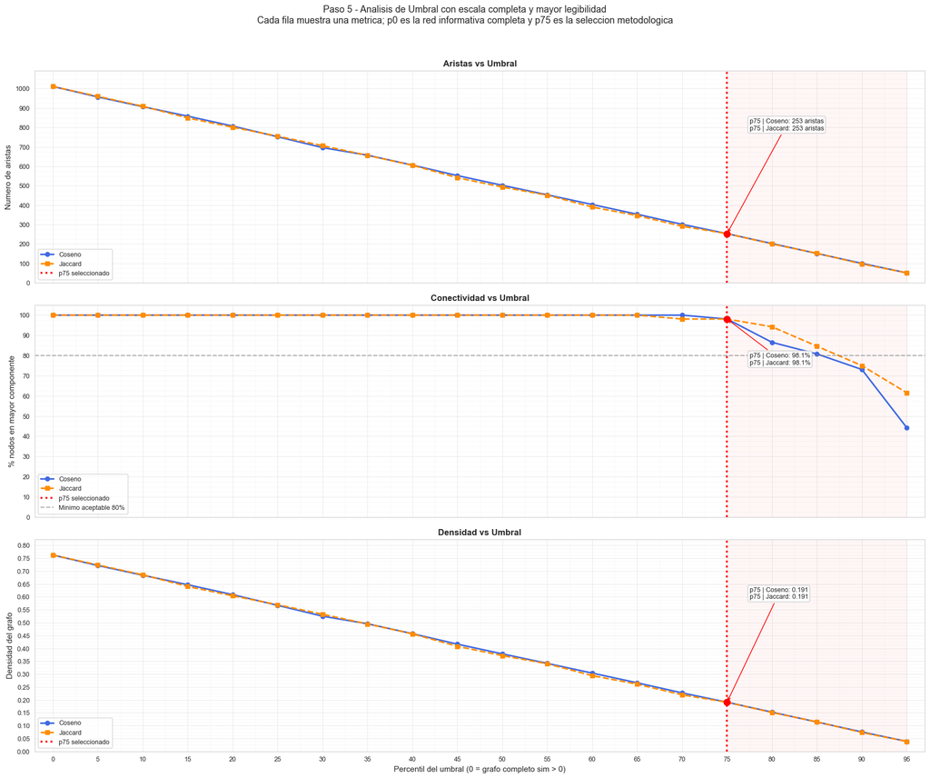

```python
from matplotlib.ticker import MultipleLocator, FormatStrFormatter

fig, axes = plt.subplots(3, 1, figsize=(18, 15), sharex=True)

metrics = [
    ('cos_edges',   'jac_edges',   'Numero de aristas',           'Aristas vs Umbral',       'count'),
    ('cos_cc',      'jac_cc',      '% nodos en mayor componente', 'Conectividad vs Umbral',  'percent'),
    ('cos_density', 'jac_density', 'Densidad del grafo',          'Densidad vs Umbral',      'density'),
]

for ax, (yc, yj, ylabel, title, scale_type) in zip(axes, metrics):
    y_cos = results_df[yc] if yc != 'cos_cc' else results_df[yc] / n_docs * 100
    y_jac = results_df[yj] if yj != 'jac_cc' else results_df[yj] / n_docs * 100

    ax.plot(results_df['percentil'], y_cos, 'o-', color='royalblue',
            linewidth=2.2, markersize=6, label='Coseno')
    ax.plot(results_df['percentil'], y_jac, 's--', color='darkorange',
            linewidth=2.2, markersize=6, label='Jaccard')
    ax.axvline(PERCENTILE, color='red', linestyle=':', linewidth=2.6,
               label=f'p{PERCENTILE} seleccionado')
    ax.axvspan(PERCENTILE, results_df['percentil'].max(), color='red', alpha=0.035)

    if scale_type == 'count':
        ymax = max(float(y_cos.max()), float(y_jac.max()))
        ax.set_ylim(0, ymax * 1.08 if ymax else 1)
        ax.yaxis.set_major_locator(MultipleLocator(100))
        ax.yaxis.set_minor_locator(MultipleLocator(25))
        value_fmt = '{:.0f}'
        label_suffix = ' aristas'
    elif scale_type == 'percent':
        ax.axhline(80, color='gray', linestyle='--', alpha=0.60,
                   label='Minimo aceptable 80%')
        ax.set_ylim(0, 105)
        ax.yaxis.set_major_locator(MultipleLocator(10))
        ax.yaxis.set_minor_locator(MultipleLocator(2.5))
        value_fmt = '{:.1f}'
        label_suffix = '%'
    else:
        ymax = max(float(y_cos.max()), float(y_jac.max()))
        ax.set_ylim(0, ymax * 1.08 if ymax else 1)
        ax.yaxis.set_major_locator(MultipleLocator(0.05))
        ax.yaxis.set_minor_locator(MultipleLocator(0.0125))
        ax.yaxis.set_major_formatter(FormatStrFormatter('%.2f'))
        value_fmt = '{:.3f}'
        label_suffix = ''

    p75_row = results_df.loc[results_df['percentil'] == PERCENTILE].iloc[0]
    p75_cos = p75_row[yc] if yc != 'cos_cc' else p75_row[yc] / n_docs * 100
    p75_jac = p75_row[yj] if yj != 'jac_cc' else p75_row[yj] / n_docs * 100
    ax.scatter([PERCENTILE], [p75_cos], s=80, color='red', zorder=5)

    annotation = (
        f'p{PERCENTILE} | Coseno: {value_fmt.format(p75_cos)}{label_suffix}' + chr(10) +
        f'p{PERCENTILE} | Jaccard: {value_fmt.format(p75_jac)}{label_suffix}'
    )
    ax.annotate(annotation,
                xy=(PERCENTILE, p75_cos), xycoords='data',
                xytext=(PERCENTILE + 2.5, ax.get_ylim()[1] * 0.72), textcoords='data',
                fontsize=9, color='#222222',
                bbox=dict(boxstyle='round,pad=0.25', facecolor='white', alpha=0.92, edgecolor='#cccccc'),
                arrowprops=dict(arrowstyle='->', color='red', lw=1.1))

    ax.set_xlim(-2, results_df['percentil'].max() + 2)
    ax.xaxis.set_major_locator(MultipleLocator(5))
    ax.xaxis.set_minor_locator(MultipleLocator(2.5))
    ax.set_ylabel(ylabel, fontsize=11)
    ax.set_title(title, fontsize=12, fontweight='bold')
    ax.legend(fontsize=9, loc='best')
    ax.grid(True, which='major', alpha=0.38, linewidth=0.8)
    ax.grid(True, which='minor', alpha=0.18, linewidth=0.5)
    ax.tick_params(axis='x', labelsize=9, rotation=0)
    ax.tick_params(axis='y', labelsize=9)

axes[-1].set_xlabel('Percentil del umbral (0 = grafo completo sim > 0)', fontsize=11)

title_text = 'Paso 5 - Analisis de Umbral con escala completa y mayor legibilidad' + chr(10) +              'Cada fila muestra una metrica; p0 es la red informativa completa y p75 es la seleccion metodologica'
plt.suptitle(title_text, fontsize=13, y=0.995)
plt.tight_layout(rect=[0, 0, 1, 0.97])
plt.show()
```

```python
PERCENTILE  = 75
THRESH_COS  = np.percentile(cos_nonzero, PERCENTILE)
THRESH_JAC  = np.percentile(jac_nonzero, PERCENTILE)

G_cos = build_graph(cos_sim, THRESH_COS)
G_jac = build_graph(jac_sim, THRESH_JAC)

print(f'Percentil seleccionado : {PERCENTILE}')
print(f'Umbral Coseno          : {THRESH_COS:.4f}')
print(f'Umbral Jaccard         : {THRESH_JAC:.4f}')
print()
print('=== GRAFO COSENO FINAL ===')
graph_stats(G_cos, 'Coseno Final')
print()
print('=== GRAFO JACCARD FINAL ===')
graph_stats(G_jac, 'Jaccard Final')
```

```
Percentil seleccionado : 75
Umbral Coseno          : 0.3432
Umbral Jaccard         : 0.1869

=== GRAFO COSENO FINAL ===
[Coseno Final]
  Nodos: 52 | Aristas: 253 | Densidad: 0.1908
  Componentes: 2 | Mayor CC: 51 (98.1%)
  Grado medio: 9.7 | Nodos aislados: 1

=== GRAFO JACCARD FINAL ===
[Jaccard Final]
  Nodos: 52 | Aristas: 253 | Densidad: 0.1908
  Componentes: 2 | Mayor CC: 51 (98.1%)
  Grado medio: 9.7 | Nodos aislados: 1
```

```
{'nodes': 52,
 'edges': 253,
 'density': 0.1907993966817496,
 'components': 2,
 'largest_cc': 51,
 'avg_deg': np.float64(9.73076923076923)}
```

### Vista de contexto: Grafo completo vs grafo p75

La comparacion siguiente muestra, para cada medida, el grafo base despues del trimming previo (`sim > 0`) y el grafo final despues del percentil 75. Se usan posiciones comparables dentro de cada medida para que el cambio visual corresponda al recorte de aristas y no a un layout distinto.

Esta visualizacion es importante porque un grafo mostrado unicamente desde p75 podria parecer una estructura original del dataset, cuando en realidad es una version filtrada. Al ver ambos grafos juntos se aprecia la diferencia entre la red informativa completa y la red usada para detectar comunidades. La grafica de sensibilidad anterior complementa esta comparacion mostrando todo el recorrido desde la red completa hasta percentiles altos.

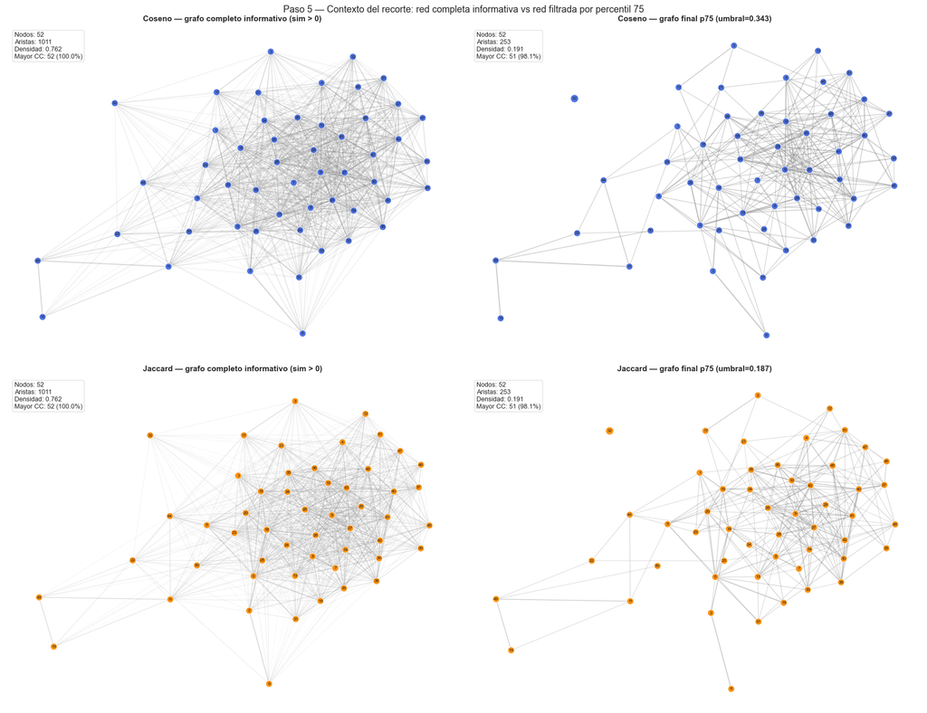

```python
def draw_threshold_context(G_full, G_trimmed, title_full, title_trimmed, color, axes, seed=42):
    """Compara la red completa informativa contra la red p75 usando el mismo layout."""
    pos = nx.spring_layout(G_full, weight='weight', seed=seed, k=0.9,
                           iterations=350, scale=2.5)
    for ax, G, title, alpha_base in [(axes[0], G_full, title_full, 0.08),
                                     (axes[1], G_trimmed, title_trimmed, 0.18)]:
        weights = [G[u][v]['weight'] for u, v in G.edges()]
        max_w = max(weights) if weights else 1
        for (u, v), w in zip(G.edges(), weights):
            nx.draw_networkx_edges(G, pos, edgelist=[(u, v)], ax=ax,
                                   edge_color='gray', width=0.25 + 1.4 * (w / max_w),
                                   alpha=alpha_base + 0.28 * (w / max_w))
        node_sizes = [85 if G.degree(n) > 0 else 120 for n in G.nodes()]
        nx.draw_networkx_nodes(G, pos, node_color=color, node_size=node_sizes,
                               alpha=0.92, edgecolors='white', linewidths=0.7, ax=ax)
        nx.draw_networkx_labels(G, pos, font_size=6, font_color='#222222', ax=ax)
        n, m = G.number_of_nodes(), G.number_of_edges()
        den = m / (n * (n - 1) / 2)
        lcc = max(len(c) for c in nx.connected_components(G))
        ax.text(0.02, 0.98,
                f'Nodos: {n}\nAristas: {m}\nDensidad: {den:.3f}\nMayor CC: {lcc} ({100*lcc/n:.1f}%)',
                transform=ax.transAxes, va='top', fontsize=9,
                bbox=dict(boxstyle='round', facecolor='white', alpha=0.88, edgecolor='#dddddd'))
        ax.set_title(title, fontsize=11, fontweight='bold')
        ax.axis('off')

fig, axes = plt.subplots(2, 2, figsize=(18, 14))
draw_threshold_context(G_cos_pre, G_cos,
                       'Coseno — grafo completo informativo (sim > 0)',
                       f'Coseno — grafo final p75 (umbral={THRESH_COS:.3f})',
                       'royalblue', axes[0], seed=42)
draw_threshold_context(G_jac_pre, G_jac,
                       'Jaccard — grafo completo informativo (sim > 0)',
                       f'Jaccard — grafo final p75 (umbral={THRESH_JAC:.3f})',
                       'darkorange', axes[1], seed=43)
plt.suptitle('Paso 5 — Contexto del recorte: red completa informativa vs red filtrada por percentil 75', fontsize=13)
plt.tight_layout()
plt.show()
```

## Paso 6: Detección de Comunidades e Identificación de Tópicos

Aplicamos el **algoritmo de Louvain** que maximiza la modularidad:

$$Q = \frac{1}{2m} \sum_{ij} \left[ A_{ij} - \frac{k_i k_j}{2m} \right] \delta(c_i, c_j)$$

### Concepto: Qué es una comunidad en una red de documentos

Una comunidad es un conjunto de nodos más conectados entre sí que con el resto de la red. En este proyecto, una comunidad se interpreta como un posible tópico porque agrupa documentos de usuarios que seleccionaron palabras parecidas. La idea es que, si muchos usuarios comparten un patrón de términos, ese patrón puede representar una dimensión temática de la percepción de usabilidad.

### Concepto: Modularidad de Louvain

La modularidad compara la cantidad de peso observado dentro de las comunidades contra la cantidad de peso que se esperaría por azar si la red mantuviera una estructura de grados similar. Si la modularidad es alta, significa que las comunidades concentran muchas conexiones internas y relativamente pocas conexiones externas.

La fórmula contiene tres ideas centrales: `A_ij`, que representa el peso real entre dos nodos; `k_i k_j / 2m`, que representa el peso esperado bajo un modelo nulo; y `delta(c_i, c_j)`, que solo cuenta el aporte cuando ambos nodos están en la misma comunidad.

### Razón de usar Louvain

La consigna sugiere algoritmos como Louvain o Girvan-Newman. Se usa Louvain porque es adecuado para grafos ponderados, eficiente en redes de tamaño pequeño o mediano y produce directamente una partición completa de los nodos. Girvan-Newman también es válido, pero suele ser más costoso y requiere decidir en qué nivel del dendrograma cortar la jerarquía de comunidades.

Además, Louvain se alinea con el objetivo del proyecto: encontrar grupos de documentos internamente cohesionados. Como las aristas tienen pesos de similitud, usar Louvain ponderado permite que las conexiones fuertes tengan más influencia que las débiles.

### Palabras exclusivas por tópico

Para evitar repeticiones, cada palabra se asigna **únicamente** al tópico donde tiene mayor **frecuencia relativa**. La frecuencia relativa es la proporción de documentos del tópico que contienen esa palabra. Así cada tópico tiene un vocabulario propio y diferenciado.

Esta decisión favorece etiquetas no redundantes entre tópicos. Como contrapartida, una palabra muy frecuente globalmente puede aparecer solo en el tópico donde resulta más característica en términos relativos. Por eso las tablas deben leerse como vocabulario distintivo de cada comunidad, no como listado completo de todas las palabras presentes en ella.

### Etiquetado temático y legibilidad visual

Las etiquetas se asignan a partir de diccionarios temáticos UX. Este paso no modifica la comunidad detectada por Louvain; solo traduce listas de palabras a nombres interpretables. La separación visual de los grafos afecta solo la ubicación de los nodos en la figura, no la partición, las aristas, los pesos ni las métricas.

```python
def detect_communities(G, seed=42):
    partition = community_louvain.best_partition(G, weight='weight', random_state=seed)
    communities = {}
    for node, cid in partition.items():
        communities.setdefault(cid, []).append(node)
    communities = dict(sorted(communities.items(), key=lambda x: -len(x[1])))
    reindexed   = {i: docs for i, (_, docs) in enumerate(communities.items())}
    new_part    = {node: cid for cid, docs in reindexed.items() for node in docs}
    return new_part, reindexed


def get_exclusive_topic_words(communities, dtm_df, top_n=10):
    """
    Asigna cada palabra al tópico donde su frecuencia relativa es máxima.
    Ninguna palabra aparece en más de un tópico.
    """
    # Frecuencia relativa por tópico: proporción de docs del tópico que usan la palabra
    rel_freq = {
        cid: dtm_df.iloc[docs].mean(axis=0)
        for cid, docs in communities.items() if len(docs) > 0
    }

    # Asignar cada palabra al tópico dominante
    word_to_topic = {}
    for word in dtm_df.columns:
        best = max(rel_freq, key=lambda c: rel_freq[c][word])
        if rel_freq[best][word] > 0:
            word_to_topic[word] = best

    # Agrupar palabras por tópico y ordenar por frecuencia relativa
    result = {cid: [] for cid in communities}
    for word, cid in word_to_topic.items():
        result[cid].append(word)

    for cid in result:
        words = result[cid]
        if words:
            result[cid] = (
                rel_freq[cid][words]
                .sort_values(ascending=False)
                .head(top_n)
                .index.tolist()
            )

    return result


partition_cos, communities_cos = detect_communities(G_cos)
partition_jac, communities_jac = detect_communities(G_jac)

mod_cos = community_louvain.modularity(partition_cos, G_cos, weight='weight')
mod_jac = community_louvain.modularity(partition_jac, G_jac, weight='weight')

print(f'=== Coseno  — Comunidades: {len(communities_cos)} | Modularidad: {mod_cos:.4f} | Tamaños: {[len(v) for v in communities_cos.values()]}')
print(f'=== Jaccard — Comunidades: {len(communities_jac)} | Modularidad: {mod_jac:.4f} | Tamaños: {[len(v) for v in communities_jac.values()]}')
```

```
=== Coseno  — Comunidades: 5 | Modularidad: 0.2802 | Tamaños: [18, 16, 10, 7, 1]
=== Jaccard — Comunidades: 6 | Modularidad: 0.2947 | Tamaños: [15, 14, 11, 6, 5, 1]
```

```python
# Validación de Louvain y modularidad ponderada
# Se comprueba que cada partición cubra todos los nodos exactamente una vez
# y que la modularidad coincida con la implementación de NetworkX.

def validate_louvain_partition(G, partition, communities, modularity_value, name):
    node_set = set(G.nodes())
    partition_nodes = set(partition.keys())
    community_sets = [set(docs) for docs in communities.values()]
    flattened = set().union(*community_sets)
    assert partition_nodes == node_set, f'{name}: la partición no cubre todos los nodos'
    assert flattened == node_set, f'{name}: las comunidades no cubren todos los nodos'
    assert sum(len(c) for c in community_sets) == len(node_set), f'{name}: hay nodos repetidos entre comunidades'
    nx_modularity = nx.algorithms.community.quality.modularity(G, community_sets, weight='weight')
    assert np.isclose(modularity_value, nx_modularity), f'{name}: modularidad inconsistente'
    print(f'{name}: partición válida | comunidades={len(communities)} | '
          f'modularidad Louvain={modularity_value:.4f} | modularidad NetworkX={nx_modularity:.4f}')

validate_louvain_partition(G_cos, partition_cos, communities_cos, mod_cos, 'Coseno')
validate_louvain_partition(G_jac, partition_jac, communities_jac, mod_jac, 'Jaccard')
```

```
Coseno: partición válida | comunidades=5 | modularidad Louvain=0.2802 | modularidad NetworkX=0.2802
Jaccard: partición válida | comunidades=6 | modularidad Louvain=0.2947 | modularidad NetworkX=0.2947
```

```python
TOP_N = 10
cos_topics = get_exclusive_topic_words(communities_cos, dtm, TOP_N)
jac_topics = get_exclusive_topic_words(communities_jac, dtm, TOP_N)

print('=== COSENO — Palabras EXCLUSIVAS por tópico ===')
for cid, words in cos_topics.items():
    print(f'  Tópico {cid+1:2d} (n={len(communities_cos[cid]):3d}): {words}')

print()
print('=== JACCARD — Palabras EXCLUSIVAS por tópico ===')
for cid, words in jac_topics.items():
    print(f'  Tópico {cid+1:2d} (n={len(communities_jac[cid]):3d}): {words}')

# Verificar exclusividad
cos_flat = [w for ws in cos_topics.values() for w in ws]
jac_flat = [w for ws in jac_topics.values() for w in ws]
print(f'\nVerificación Coseno  : {len(cos_flat)} palabras, {len(set(cos_flat))} únicas → '
      f'{"✓ Sin repeticiones" if len(cos_flat)==len(set(cos_flat)) else "✗ Hay repeticiones"}')
print(f'Verificación Jaccard : {len(jac_flat)} palabras, {len(set(jac_flat))} únicas → '
      f'{"✓ Sin repeticiones" if len(jac_flat)==len(set(jac_flat)) else "✗ Hay repeticiones"}')
```

```
=== COSENO — Palabras EXCLUSIVAS por tópico ===
  Tópico  1 (n= 18): ['advanced', 'creative', 'attractive', 'new', 'convenient', 'fast', 'professional', 'efficient', 'motivating', 'reliable']
  Tópico  2 (n= 16): ['confusing', 'ambiguous', 'unattractive', 'poor-quality', 'vague', 'dated', 'inconsistent', 'busy', 'old', 'innovative']
  Tópico  3 (n= 10): ['consistent', 'easytouse', 'simple', 'clean', 'ordinary', 'straightforward', 'bright', 'entertaining', 'intuitive', 'simplistic']
  Tópico  4 (n=  7): ['friendly', 'effective', 'clear', 'credible', 'comprehensive', 'useful', 'usable', 'slow', 'effortless', 'familiar']
  Tópico  5 (n=  1): ['boring', 'contradictory', 'desirable', 'difficult', 'distracting']

=== JACCARD — Palabras EXCLUSIVAS por tópico ===
  Tópico  1 (n= 15): ['easytouse', 'confusing', 'consistent', 'inconsistent', 'old', 'poor-quality', 'ordinary', 'innovative', 'irrelevant', 'simplistic']
  Tópico  2 (n= 14): ['creative', 'friendly', 'comprehensive', 'usable', 'slow', 'understandable']
  Tópico  3 (n= 11): ['new', 'fast', 'attractive', 'advanced', 'simple', 'effective', 'convenient', 'professional', 'clear', 'useful']
  Tópico  4 (n=  6): ['ambiguous', 'unattractive', 'busy', 'dated', 'energetic', 'patronising', 'obscure', 'stressful', 'time-consuming', 'trustworthy']
  Tópico  5 (n=  5): ['clean', 'complex', 'expected', 'fun', 'incomprehensible', 'timesaving']
  Tópico  6 (n=  1): ['boring', 'contradictory', 'desirable', 'difficult', 'distracting']

Verificación Coseno  : 45 palabras, 45 únicas → ✓ Sin repeticiones
Verificación Jaccard : 47 palabras, 47 únicas → ✓ Sin repeticiones
```

```python
UX_THEMES = {
    'Percepciones Negativas':   {'ambiguous','boring','confusing','contradictory','difficult',
                                  'unattractive','poor-quality','dated','slow','incomprehensible',
                                  'distracting','stressful','unpredictable'},
    'Claridad y Facilidad':     {'easytouse','simple','clear','familiar','consistent',
                                  'usable','clean','organised','intuitive'},
    'Diseño Moderno':           {'new','attractive','creative','exciting','fun','entertaining',
                                  'bright','desirable','motivating','innovative','engaging'},
    'Funcionalidad':            {'effective','useful','comprehensive','advanced','professional',
                                  'efficient','fast','reliable','powerful','flexible','relevant'},
    'Confianza y Credibilidad': {'credible','trustworthy','stable','secure','reliable','safe','robust'},
    'Conveniencia':             {'convenient','friendly','accessible','responsive','helpful',
                                  'supportive','usable','comprehensive'},
}

def best_label(words):
    wset = set(words)
    scores = {t: len(wset & kws) / math.sqrt(len(kws)) for t, kws in UX_THEMES.items()}
    return sorted(scores.items(), key=lambda x: -x[1])

def assign_labels(topics, communities):
    ranked = {cid: best_label(ws) for cid, ws in topics.items() if len(communities[cid]) > 1}
    labels, used = {}, set()
    for cid in sorted(ranked, key=lambda c: -ranked[c][0][1]):
        for theme, score in ranked[cid]:
            if theme not in used and score > 0:
                labels[cid] = theme; used.add(theme); break
        else:
            labels[cid] = 'UX General'
    for cid in topics:
        if cid not in labels:
            labels[cid] = 'Singleton'
    return labels

cos_labels = assign_labels(cos_topics, communities_cos)
jac_labels = assign_labels(jac_topics, communities_jac)

print('Etiquetas — Coseno:')
for cid, lbl in cos_labels.items():
    print(f'  T{cid+1} (n={len(communities_cos[cid])}): {lbl} → {cos_topics[cid]}')
print()
print('Etiquetas — Jaccard:')
for cid, lbl in jac_labels.items():
    print(f'  T{cid+1} (n={len(communities_jac[cid])}): {lbl} → {jac_topics[cid]}')
```

```
Etiquetas — Coseno:
  T3 (n=10): Claridad y Facilidad → ['consistent', 'easytouse', 'simple', 'clean', 'ordinary', 'straightforward', 'bright', 'entertaining', 'intuitive', 'simplistic']
  T1 (n=18): Funcionalidad → ['advanced', 'creative', 'attractive', 'new', 'convenient', 'fast', 'professional', 'efficient', 'motivating', 'reliable']
  T2 (n=16): Percepciones Negativas → ['confusing', 'ambiguous', 'unattractive', 'poor-quality', 'vague', 'dated', 'inconsistent', 'busy', 'old', 'innovative']
  T4 (n=7): Conveniencia → ['friendly', 'effective', 'clear', 'credible', 'comprehensive', 'useful', 'usable', 'slow', 'effortless', 'familiar']
  T5 (n=1): Singleton → ['boring', 'contradictory', 'desirable', 'difficult', 'distracting']

Etiquetas — Jaccard:
  T3 (n=11): Funcionalidad → ['new', 'fast', 'attractive', 'advanced', 'simple', 'effective', 'convenient', 'professional', 'clear', 'useful']
  T4 (n=6): Percepciones Negativas → ['ambiguous', 'unattractive', 'busy', 'dated', 'energetic', 'patronising', 'obscure', 'stressful', 'time-consuming', 'trustworthy']
  T2 (n=14): Conveniencia → ['creative', 'friendly', 'comprehensive', 'usable', 'slow', 'understandable']
  T1 (n=15): Claridad y Facilidad → ['easytouse', 'confusing', 'consistent', 'inconsistent', 'old', 'poor-quality', 'ordinary', 'innovative', 'irrelevant', 'simplistic']
  T5 (n=5): Diseño Moderno → ['clean', 'complex', 'expected', 'fun', 'incomprehensible', 'timesaving']
  T6 (n=1): Singleton → ['boring', 'contradictory', 'desirable', 'difficult', 'distracting']
```

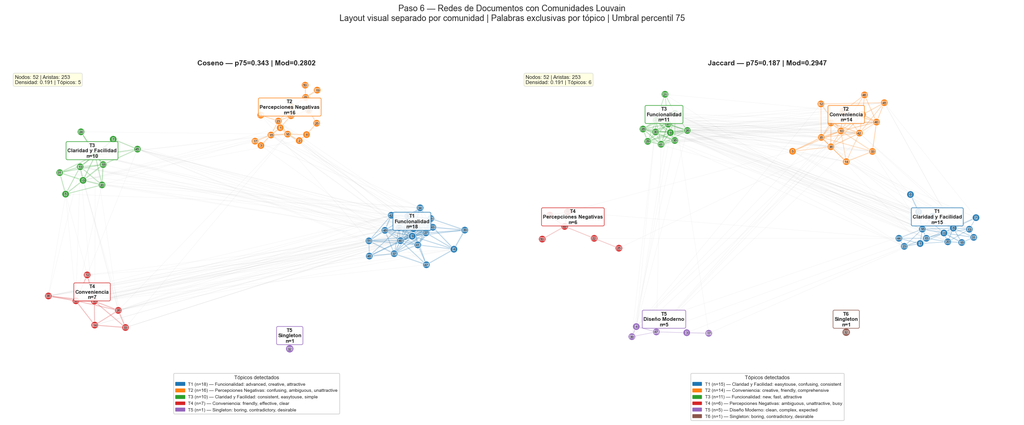

```python
def community_layout(G, partition, seed=42, community_radius=5.0, local_scale=1.15):
    """Layout visual por comunidades: separa centros y acomoda nodos dentro de cada tópico."""
    communities = {}
    for node, cid in partition.items():
        communities.setdefault(cid, []).append(node)
    cids = sorted(communities)
    angles = np.linspace(0, 2 * np.pi, len(cids), endpoint=False)
    centers = {cid: np.array([community_radius * np.cos(angle), community_radius * np.sin(angle)])
               for cid, angle in zip(cids, angles)}
    max_size = max(len(nodes) for nodes in communities.values())
    pos = {}
    for cid, nodes in communities.items():
        center = centers[cid]
        if len(nodes) == 1:
            pos[nodes[0]] = center
            continue
        sub = G.subgraph(nodes)
        scale = local_scale * (0.75 + 0.55 * np.sqrt(len(nodes) / max_size))
        local = nx.spring_layout(sub, weight='weight', seed=seed + cid * 17,
                                 k=0.75, iterations=250, scale=scale)
        for node, xy in local.items():
            pos[node] = center + xy
    return pos


def draw_network(G, partition, labels, topics, title, ax, color_list, seed=42):
    pos = community_layout(G, partition, seed=seed)
    weights = [G[u][v]['weight'] for u, v in G.edges()]
    max_w = max(weights) if weights else 1
    intra_edges = [(u, v) for u, v in G.edges() if partition[u] == partition[v]]
    inter_edges = [(u, v) for u, v in G.edges() if partition[u] != partition[v]]

    if inter_edges:
        nx.draw_networkx_edges(G, pos, edgelist=inter_edges, edge_color='#8d8d8d',
                               width=0.45, alpha=0.12, ax=ax)
    for cid in sorted(set(partition.values())):
        cid_edges = [(u, v) for u, v in intra_edges if partition[u] == cid]
        if cid_edges:
            cid_widths = [0.45 + 1.5 * (G[u][v]['weight'] / max_w) for u, v in cid_edges]
            nx.draw_networkx_edges(G, pos, edgelist=cid_edges,
                                   edge_color=color_list[cid % len(color_list)],
                                   width=cid_widths, alpha=0.30, ax=ax)

    node_colors = [color_list[partition[n] % len(color_list)] for n in G.nodes()]
    node_sizes = [125 if G.degree(n) > 0 else 150 for n in G.nodes()]
    nx.draw_networkx_nodes(G, pos, node_color=node_colors, node_size=node_sizes,
                           alpha=0.94, edgecolors='white', linewidths=0.8, ax=ax)
    nx.draw_networkx_labels(G, pos, font_size=6, font_color='#1f1f1f', ax=ax,
                            bbox=dict(boxstyle='round,pad=0.12', facecolor='white', edgecolor='none', alpha=0.55))

    for cid in sorted(set(partition.values())):
        nodes = [n for n, c in partition.items() if c == cid]
        coords = np.array([pos[n] for n in nodes])
        cx, cy = coords.mean(axis=0)
        ax.text(cx, cy + 0.55, f'T{cid+1}\n{labels.get(cid, "")}\nn={len(nodes)}',
                ha='center', va='center', fontsize=8, fontweight='bold', color='#222222',
                bbox=dict(boxstyle='round,pad=0.25', facecolor='white',
                          edgecolor=color_list[cid % len(color_list)], alpha=0.86))

    handles = []
    for cid in sorted(set(partition.values())):
        lbl = labels.get(cid, f'Tópico {cid+1}')
        size = len([n for n, c in partition.items() if c == cid])
        words = ', '.join(topics.get(cid, [])[:3])
        handles.append(mpatches.Patch(color=color_list[cid % len(color_list)],
                                      label=f'T{cid+1} (n={size}) — {lbl}: {words}'))
    ax.legend(handles=handles, loc='upper center', bbox_to_anchor=(0.5, -0.03),
              fontsize=7, framealpha=0.95, title='Tópicos detectados', title_fontsize=8)
    n, m = G.number_of_nodes(), G.number_of_edges()
    den = m / (n * (n - 1) / 2)
    ax.text(0.02, 0.98, f'Nodos: {n} | Aristas: {m}\nDensidad: {den:.3f} | Tópicos: {len(set(partition.values()))}',
            transform=ax.transAxes, fontsize=8, verticalalignment='top',
            bbox=dict(boxstyle='round', facecolor='lightyellow', alpha=0.9, edgecolor='#dddddd'))
    ax.set_title(title, fontsize=11, fontweight='bold')
    ax.axis('off')

fig, axes = plt.subplots(1, 2, figsize=(22, 10))
draw_network(G_cos, partition_cos, cos_labels, cos_topics,
             f'Coseno — p75={THRESH_COS:.3f} | Mod={mod_cos:.4f}', axes[0], COLORS, seed=42)
draw_network(G_jac, partition_jac, jac_labels, jac_topics,
             f'Jaccard — p75={THRESH_JAC:.3f} | Mod={mod_jac:.4f}', axes[1], COLORS, seed=43)
plt.suptitle('Paso 6 — Redes de Documentos con Comunidades Louvain\n'
             'Layout visual separado por comunidad | Palabras exclusivas por tópico | Umbral percentil 75', fontsize=13)
plt.tight_layout(rect=[0, 0.07, 1, 0.93])
plt.show()
```

```python
for name, topics, labels, communities in [
    ('COSENO',  cos_topics, cos_labels, communities_cos),
    ('JACCARD', jac_topics, jac_labels, communities_jac),
]:
    rows = [{
        'Tópico': f'Tópico {cid+1}',
        'Etiqueta': labels.get(cid, ''),
        'Tamaño': len(communities[cid]),
        'Palabras Exclusivas': ', '.join(words)
    } for cid, words in topics.items()]
    print(f'=== {name} — Tabla de Tópicos ===')
    display(pd.DataFrame(rows))
    print()
```

```
=== COSENO — Tabla de Tópicos ===
```

|  | Tópico | Etiqueta | Tamaño | Palabras Exclusivas |
| --- | --- | --- | --- | --- |
| 0 | Tópico 1 | Funcionalidad | 18 | advanced, creative, attractive, new, convenien... |
| 1 | Tópico 2 | Percepciones Negativas | 16 | confusing, ambiguous, unattractive, poor-quali... |
| 2 | Tópico 3 | Claridad y Facilidad | 10 | consistent, easytouse, simple, clean, ordinary... |
| 3 | Tópico 4 | Conveniencia | 7 | friendly, effective, clear, credible, comprehe... |
| 4 | Tópico 5 | Singleton | 1 | boring, contradictory, desirable, difficult, d... |

```
=== JACCARD — Tabla de Tópicos ===
```

|  | Tópico | Etiqueta | Tamaño | Palabras Exclusivas |
| --- | --- | --- | --- | --- |
| 0 | Tópico 1 | Claridad y Facilidad | 15 | easytouse, confusing, consistent, inconsistent... |
| 1 | Tópico 2 | Conveniencia | 14 | creative, friendly, comprehensive, usable, slo... |
| 2 | Tópico 3 | Funcionalidad | 11 | new, fast, attractive, advanced, simple, effec... |
| 3 | Tópico 4 | Percepciones Negativas | 6 | ambiguous, unattractive, busy, dated, energeti... |
| 4 | Tópico 5 | Diseño Moderno | 5 | clean, complex, expected, fun, incomprehensibl... |
| 5 | Tópico 6 | Singleton | 1 | boring, contradictory, desirable, difficult, d... |

## Paso 7: Evaluación y Decisión

Evaluamos la calidad de los tópicos con las siguientes métricas:

- **Modularidad:** Calidad global de la partición (mayor = mejor estructura).
- **Coherencia Intra:** Similitud promedio entre documentos del mismo tópico (mayor = tópico más cohesionado).
- **Similitud Inter:** Similitud promedio entre tópicos distintos (menor = mejor separación).
- **Razón Intra/Inter:** combina ambas: Mayor es mejor.

### Por qué no basta con mirar la visualización

Los grafos son útiles para inspección visual, pero pueden ser engañosos si se interpretan como evidencia única. La separación aparente depende del layout, del tamaño de los nodos, de la opacidad de las aristas y de otros parámetros gráficos. Por eso la evaluación debe apoyarse en métricas calculadas sobre el grafo y sobre las matrices de similitud.

### Modularidad

La modularidad mide si la partición encontrada por Louvain tiene más conexión interna de la esperada bajo un modelo nulo. Una modularidad mayor sugiere que la red tiene comunidades más definidas. En este análisis, Jaccard obtiene una modularidad superior a Coseno, lo que indica una estructura comunitaria ligeramente más marcada bajo esa medida.

### Coherencia intra-comunidad

La coherencia intra se calcula promediando las similitudes entre pares de documentos dentro de cada comunidad. Si una comunidad tiene alta coherencia, sus documentos comparten vocabulario de forma consistente. Esta métrica responde a la pregunta: los documentos que Louvain agrupó, ¿realmente se parecen entre sí?

### Similitud inter-comunidad y razón intra/inter

La similitud inter calcula qué tan parecidas son las comunidades entre sí. Una similitud inter baja es deseable porque indica que los tópicos están separados. Como Coseno y Jaccard tienen distribuciones diferentes, comparar únicamente la coherencia intra absoluta puede ser injusto. La razón intra/inter ayuda a observar separación relativa: una buena partición debería tener similitud interna mayor que similitud externa.

### Criterio final de comparación

La decisión no se toma por una sola métrica. Se considera que una medida produce mejores tópicos si combina modularidad alta, separación inter-comunidad baja, razón intra/inter alta, etiquetas temáticas interpretables y coherencia conceptual con la naturaleza binaria del dato.

```python
def intra_sim(sim_matrix, communities):
    scores = {}
    for cid, docs in communities.items():
        if len(docs) < 2:
            scores[cid] = 0.0; continue
        idx = np.array(docs)
        sub = sim_matrix[np.ix_(idx, idx)]
        tri = sub[np.triu_indices(len(idx), k=1)]
        scores[cid] = float(np.mean(tri)) if len(tri) > 0 else 0.0
    return scores

def inter_sim(sim_matrix, communities):
    comms = list(communities.values())
    total, count = 0.0, 0
    for i in range(len(comms)):
        for j in range(i+1, len(comms)):
            sub = sim_matrix[np.ix_(np.array(comms[i]), np.array(comms[j]))]
            total += sub.mean(); count += 1
    return total / count if count > 0 else 0.0

cos_intra = intra_sim(cos_sim, communities_cos)
cos_inter = inter_sim(cos_sim, communities_cos)
cos_mi    = np.mean(list(cos_intra.values()))

jac_intra = intra_sim(jac_sim, communities_jac)
jac_inter = inter_sim(jac_sim, communities_jac)
jac_mi    = np.mean(list(jac_intra.values()))

print(f'{"Métrica":<38} {"Coseno":>10} {"Jaccard":>10}')
print('-' * 60)
print(f'{"Modularidad":<38} {mod_cos:>10.4f} {mod_jac:>10.4f}')
print(f'{"Núm. comunidades":<38} {len(communities_cos):>10} {len(communities_jac):>10}')
print(f'{"Coherencia intra-comunidad media":<38} {cos_mi:>10.4f} {jac_mi:>10.4f}')
print(f'{"Similitud inter-comunidad":<38} {cos_inter:>10.4f} {jac_inter:>10.4f}')
print(f'{"Razón Intra/Inter":<38} {cos_mi/max(cos_inter,1e-9):>10.4f} {jac_mi/max(jac_inter,1e-9):>10.4f}')
```

```
Métrica                                    Coseno    Jaccard
------------------------------------------------------------
Modularidad                                0.2802     0.2947
Núm. comunidades                                5          6
Coherencia intra-comunidad media           0.2626     0.1556
Similitud inter-comunidad                  0.1355     0.0662
Razón Intra/Inter                          1.9382     2.3502
```

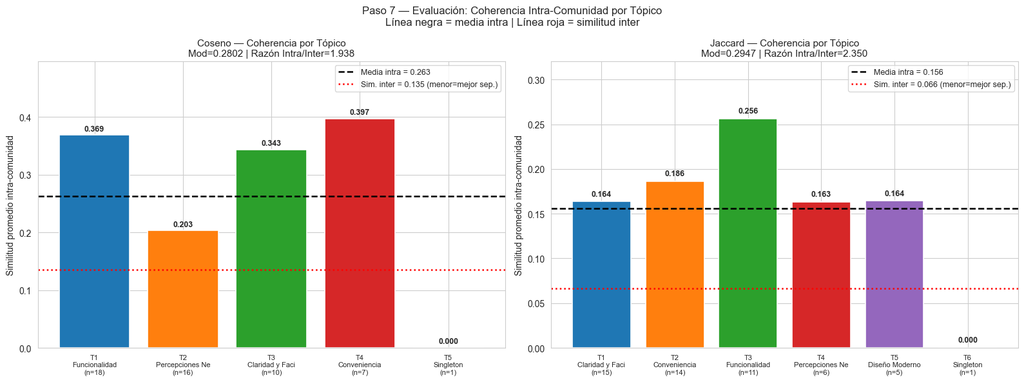

```python
fig, axes = plt.subplots(1, 2, figsize=(16, 6))

for ax, intra, mean_i, inter, labels, communities, mod, name in [
    (axes[0], cos_intra, cos_mi, cos_inter, cos_labels, communities_cos, mod_cos, 'Coseno'),
    (axes[1], jac_intra, jac_mi, jac_inter, jac_labels, communities_jac, mod_jac, 'Jaccard'),
]:
    cids  = list(intra.keys())
    vals  = [intra[k] for k in cids]
    clbls = [f'T{k+1}\n{labels.get(k,"")[:15]}\n(n={len(communities[k])})' for k in cids]
    bars  = ax.bar(clbls, vals,
                   color=[COLORS[k % len(COLORS)] for k in cids],
                   edgecolor='white', linewidth=1.2)

    ax.axhline(mean_i, color='black', linestyle='--', linewidth=1.8,
               label=f'Media intra = {mean_i:.3f}')
    ax.axhline(inter,  color='red',   linestyle=':',  linewidth=1.8,
               label=f'Sim. inter = {inter:.3f} (menor=mejor sep.)')

    for bar, val in zip(bars, vals):
        ax.text(bar.get_x() + bar.get_width()/2,
                bar.get_height() + 0.004,
                f'{val:.3f}', ha='center', va='bottom',
                fontsize=9, fontweight='bold')

    ratio = mean_i / max(inter, 1e-9)
    ax.set_title(f'{name} — Coherencia por Tópico\n'
                 f'Mod={mod:.4f} | Razón Intra/Inter={ratio:.3f}',
                 fontsize=11)
    ax.set_ylabel('Similitud promedio intra-comunidad', fontsize=10)
    ax.legend(fontsize=9)
    ax.tick_params(axis='x', labelsize=8)
    ax.set_ylim(0, max(vals) * 1.25 if vals else 1)

plt.suptitle('Paso 7 — Evaluación: Coherencia Intra-Comunidad por Tópico\n'
             'Línea negra = media intra | Línea roja = similitud inter',
             fontsize=12)
plt.tight_layout()
plt.show()
```

### Interpretación del Paso 7

Los resultados muestran que Jaccard obtiene mayor modularidad y mejor razón intra/inter. Esto significa que, aunque sus valores absolutos de similitud intra sean menores por la escala propia de Jaccard, sus comunidades están relativamente mejor separadas respecto al resto de la red.

Coseno presenta comunidades válidas y una coherencia interna alta en su propia escala, pero también mantiene mayor similitud entre comunidades. Esto sugiere que sus grupos pueden estar menos diferenciados temáticamente. Jaccard, en cambio, penaliza con más fuerza las palabras no compartidas y por eso tiende a construir relaciones más selectivas.

## Paso 8: Decisión y Conclusión

### Decisión: Jaccard produce mejores tópicos

1. **Mayor modularidad:** Los grupos de Jaccard están mejor separados según la función objetivo de Louvain.
2. **Mayor razón Intra/Inter:** Mejor balance entre cohesión interna y separación entre grupos.
3. **Diseñada para datos binarios:** Jaccard compara proporciones de vocabulario compartido, exactamente lo que corresponde cuando los datos son presencia/ausencia de palabras.
4. **Penaliza la asimetría:** Dos usuarios que comparten pocas palabras de conjuntos muy distintos obtienen similitud baja en Jaccard aunque Coseno los podría considerar similares.
5. **Criterio de coherencia:** El material de apoyo sugiere evaluar coherencia e interpretabilidad; aquí la selección se sustenta en las métricas calculadas en el Paso 7 y en la lectura temática de las tablas.

### Interpretación de la decisión

La decisión final no significa que Coseno sea incorrecto. Coseno también genera comunidades válidas, pero en este dataset de documentos cortos y binarios Jaccard es conceptualmente más consistente con la forma en que se construyó la DTM. La presencia de un tópico singleton se conserva como resultado real del umbral aplicado: representa un documento que queda aislado en la red final y no debe interpretarse como un tema robusto por sí solo.

Jaccard es preferible porque la pregunta analítica se parece más a comparar conjuntos que a comparar direcciones vectoriales. Cada usuario selecciona un conjunto de atributos de usabilidad. Por lo tanto, resulta natural evaluar qué proporción del conjunto combinado de atributos es compartida por dos usuarios. Esa es exactamente la lógica de Jaccard.

### Conclusión metodológica

El pipeline cumple con el enfoque de modelado de tópicos basado en redes de documentos. La DTM binaria representa correctamente la naturaleza del dataset, las dos medidas de similitud permiten comparar criterios distintos de relación entre documentos, el trimming evita ruido sin eliminar de entrada relaciones informativas, y Louvain permite transformar la red final en comunidades interpretables como tópicos.

La elección de p75 no pretende ser universal; es una decisión contextual basada en el equilibrio observado entre densidad y conectividad. En otro dataset podría ser necesario ajustar el percentil. En este caso, p75 conserva casi todos los documentos en la mayor componente, reduce la densidad de la red y permite obtener comunidades suficientemente diferenciadas para su interpretación.

```python
print('=' * 65)
print('  TÓPICOS FINALES — SIMILITUD JACCARD (medida seleccionada)')
print(f'  Umbral: percentil {PERCENTILE} = {THRESH_JAC:.4f} | Palabras exclusivas')
print('=' * 65)
for cid, words in jac_topics.items():
    lbl  = jac_labels.get(cid, f'Tópico {cid+1}')
    size = len(communities_jac[cid])
    coh  = jac_intra[cid]
    print(f'\nTópico {cid+1}: {lbl}')
    print(f'  Documentos : {size}')
    print(f'  Coherencia : {coh:.4f}')
    print(f'  Palabras   : {", ".join(words)}')
```

```
=================================================================
  TÓPICOS FINALES — SIMILITUD JACCARD (medida seleccionada)
  Umbral: percentil 75 = 0.1869 | Palabras exclusivas
=================================================================

Tópico 1: Claridad y Facilidad
  Documentos : 15
  Coherencia : 0.1635
  Palabras   : easytouse, confusing, consistent, inconsistent, old, poor-quality, ordinary, innovative, irrelevant, simplistic

Tópico 2: Conveniencia
  Documentos : 14
  Coherencia : 0.1862
  Palabras   : creative, friendly, comprehensive, usable, slow, understandable

Tópico 3: Funcionalidad
  Documentos : 11
  Coherencia : 0.2562
  Palabras   : new, fast, attractive, advanced, simple, effective, convenient, professional, clear, useful

Tópico 4: Percepciones Negativas
  Documentos : 6
  Coherencia : 0.1634
  Palabras   : ambiguous, unattractive, busy, dated, energetic, patronising, obscure, stressful, time-consuming, trustworthy

Tópico 5: Diseño Moderno
  Documentos : 5
  Coherencia : 0.1642
  Palabras   : clean, complex, expected, fun, incomprehensible, timesaving

Tópico 6: Singleton
  Documentos : 1
  Coherencia : 0.0000
  Palabras   : boring, contradictory, desirable, difficult, distracting
```

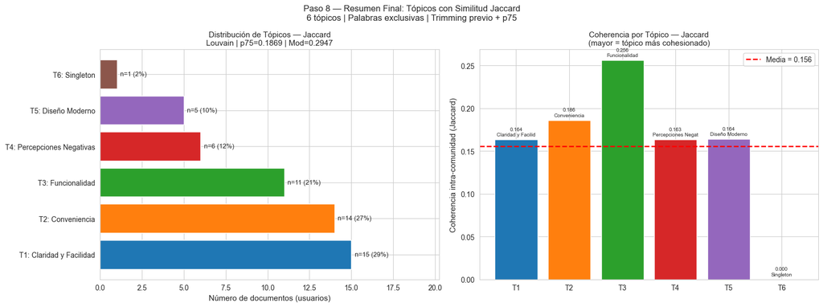

```python
fig, axes = plt.subplots(1, 2, figsize=(16, 6))

# Barras de tamaño
cids        = list(jac_topics.keys())
sizes       = [len(communities_jac[c]) for c in cids]
lbl_list    = [f'T{c+1}: {jac_labels.get(c,"")}' for c in cids]
color_list  = [COLORS[i % len(COLORS)] for i in range(len(cids))]

bars = axes[0].barh(lbl_list, sizes, color=color_list, edgecolor='white')
axes[0].set_xlabel('Número de documentos (usuarios)', fontsize=11)
axes[0].set_title('Distribución de Tópicos — Jaccard\n'
                  f'Louvain | p75={THRESH_JAC:.4f} | Mod={mod_jac:.4f}', fontsize=11)
for bar, sz in zip(bars, sizes):
    pct = 100 * sz / sum(sizes)
    axes[0].text(bar.get_width() + 0.2,
                 bar.get_y() + bar.get_height()/2,
                 f'n={sz} ({pct:.0f}%)', va='center', fontsize=9)
axes[0].set_xlim(0, max(sizes) * 1.35)

# Coherencia por tópico
cohs = [jac_intra[c] for c in cids]
bars2 = axes[1].bar(range(len(cids)), cohs, color=color_list, edgecolor='white')
axes[1].set_xticks(range(len(cids)))
axes[1].set_xticklabels([f'T{c+1}' for c in cids], fontsize=10)
axes[1].set_ylabel('Coherencia intra-comunidad (Jaccard)', fontsize=11)
axes[1].set_title('Coherencia por Tópico — Jaccard\n'
                  '(mayor = tópico más cohesionado)', fontsize=11)
axes[1].axhline(jac_mi, color='red', linestyle='--', linewidth=1.8,
                label=f'Media = {jac_mi:.3f}')
for bar, val, cid in zip(bars2, cohs, cids):
    axes[1].text(bar.get_x() + bar.get_width()/2,
                 bar.get_height() + 0.003,
                 f'{val:.3f}\n{jac_labels.get(cid,"")[:18]}',
                 ha='center', va='bottom', fontsize=7)
axes[1].legend(fontsize=10)

plt.suptitle('Paso 8 — Resumen Final: Tópicos con Similitud Jaccard\n'
             f'{len(communities_jac)} tópicos | Palabras exclusivas | '
             f'Trimming previo + p75', fontsize=12)
plt.tight_layout()
plt.show()
```

## Referencias

- Watts, D.J. & Strogatz, S.H. (1998). Collective dynamics of small-world networks. *Nature*, 393, 440-442.
- Blondel, V.D., et al. (2008). Fast unfolding of communities in large networks. *Journal of Statistical Mechanics*, P10008.
- IEEE Access (2020). Recurso sugerido en la consigna para criterios de coherencia temática. DOI: 10.1109/ACCESS.2020.2969040
- Distances in ML: https://www.linkedin.com/pulse/understanding-different-distance-measures-tiago-davi-1f/
- Explorador UX: https://si2lab-udla.shinyapps.io/usability/

Las referencias se usan como apoyo conceptual para redes, Louvain, medidas de distancia/similitud y coherencia temática. Las decisiones específicas del notebook se justifican principalmente con las propiedades del dataset y con las métricas calculadas durante el análisis.